# Ecommerce Customers Analysis

Mark Ngendo

7/9/2021

## Problem Definition

Kira Plastinina is a Russian brand that is sold through a defunct chain of retail stores in Russia, Ukraine, Kazakhstan, Belarus, China, Philippines, and Armenia. The brand’s Sales and Marketing team would like to understand their customer’s behavior from data that they have collected over the past year. More specifically, they would like to learn the characteristics of customer groups.

## Defining the Metric of Success

To use Unsupervised learning algorithms on the given data to extract useful information on customer behaviour.

## Data Relevance

The dataset can be retrieved from this link -> http://bit.ly/EcommerceCustomersDataset

The description of the dataset is as follows:

- The dataset consists of 10 numerical and 8 categorical attributes. The ‘Revenue’ attribute can be used as the class label.
- “Administrative”, “Administrative Duration”, “Informational”, “Informational Duration”, “Product Related” and “Product Related Duration” represents the number of different types of pages visited by the visitor in that session and total time spent in each of these page categories. The values of these features are derived from the URL information of the pages visited by the user and updated in real-time when a user takes an action, e.g. moving from one page to another.
- The “Bounce Rate”, “Exit Rate” and “Page Value” features represent the metrics measured by “Google Analytics” for each page in the e-commerce site.
- The value of the “Bounce Rate” feature for a web page refers to the percentage of visitors who enter the site from that page and then leave (“bounce”) without triggering any other requests to the analytics server during that session.
- The value of the “Exit Rate” feature for a specific web page is calculated as for all pageviews to the page, the percentage that was the last in the session.
- The “Page Value” feature represents the average value for a web page that a user visited before completing an e-commerce transaction.
- The “Special Day” feature indicates the closeness of the site visiting time to a specific special day (e.g. Mother’s Day, Valentine’s Day) in which the sessions are more likely to be finalized with the transaction. The value of this attribute is determined by considering the dynamics of e-commerce such as the duration between the order date and delivery date. For example, for Valentina’s day, this value takes a nonzero value between February 2 and February 12, zero before and after this date unless it is close to another special day, and its maximum value of 1 on February 8.
- The dataset also includes the operating system, browser, region, traffic type, visitor type as returning or new visitor, a Boolean value indicating whether the date of the visit is weekend, and month of the year.

## Loading Libraries

```r
library(caret)
library(Amelia)
library(e1071)
library(factoextra)
```

```r
library(ggplot2)
library(CatEncoders)
library(cluster)
library(purrr)
```

## Loading the data

```r
df <- read.csv("http://bit.ly/EcommerceCustomersDataset")
```

### Preview of the Dataset

```r
head(df)
```

```
##   Administrative Administrative_Duration Informational Informational_Duration
## 1              0                       0             0                      0
## 2              0                       0             0                      0
## 3              0                      -1             0                     -1
## 4              0                       0             0                      0
## 5              0                       0             0                      0
## 6              0                       0             0                      0
##   ProductRelated ProductRelated_Duration BounceRates ExitRates PageValues
## 1              1                0.000000  0.20000000 0.2000000          0
## 2              2               64.000000  0.00000000 0.1000000          0
## 3              1               -1.000000  0.20000000 0.2000000          0
## 4              2                2.666667  0.05000000 0.1400000          0
## 5             10              627.500000  0.02000000 0.0500000          0
## 6             19              154.216667  0.01578947 0.0245614          0
##   SpecialDay Month OperatingSystems Browser Region TrafficType
## 1          0   Feb                1       1      1           1
## 2          0   Feb                2       2      1           2
## 3          0   Feb                4       1      9           3
## 4          0   Feb                3       2      2           4
## 5          0   Feb                3       3      1           4
## 6          0   Feb                2       2      1           3
##         VisitorType Weekend Revenue
## 1 Returning_Visitor   FALSE   FALSE
## 2 Returning_Visitor   FALSE   FALSE
## 3 Returning_Visitor   FALSE   FALSE
## 4 Returning_Visitor   FALSE   FALSE
## 5 Returning_Visitor    TRUE   FALSE
## 6 Returning_Visitor   FALSE   FALSE
```

## Data Cleaning

### Completeness

```r
# checking for missing values
colSums(is.na(df))
```

```
##          Administrative Administrative_Duration           Informational
##                      14                      14                      14
##  Informational_Duration          ProductRelated ProductRelated_Duration
##                      14                      14                      14
##             BounceRates               ExitRates              PageValues
##                      14                      14                       0
##              SpecialDay                   Month        OperatingSystems
##                       0                       0                       0
##                 Browser                  Region             TrafficType
##                       0                       0                       0
##             VisitorType                 Weekend                 Revenue
##                       0                       0                       0
```

```r
# dropping null values
df <- na.omit(df)
```

### Consistency

```r
# eliminating for duplicates
df <- df[!duplicated(df), ]
```

### Accuracy

```r
# casting categorical columns as factors

df$Month <- factor(df$Month)
df$OperatingSystems <- factor(df$OperatingSystems)
df$Browser <- factor(df$Browser)
df$Region <- factor(df$Region)
df$TrafficType <- factor(df$TrafficType)
df$VisitorType <- factor(df$VisitorType)
df$Weekend <- factor(df$Weekend)
df$Revenue <- factor(df$Revenue)
```

### Dataset structure

```r
str(df)
```

```
## 'data.frame':    12199 obs. of  18 variables:
##  $ Administrative         : int  0 0 0 0 0 0 0 1 0 0 ...
##  $ Administrative_Duration: num  0 0 -1 0 0 0 -1 -1 0 0 ...
##  $ Informational          : int  0 0 0 0 0 0 0 0 0 0 ...
##  $ Informational_Duration : num  0 0 -1 0 0 0 -1 -1 0 0 ...
##  $ ProductRelated         : int  1 2 1 2 10 19 1 1 2 3 ...
##  $ ProductRelated_Duration: num  0 64 -1 2.67 627.5 ...
##  $ BounceRates            : num  0.2 0 0.2 0.05 0.02 ...
##  $ ExitRates              : num  0.2 0.1 0.2 0.14 0.05 ...
##  $ PageValues             : num  0 0 0 0 0 0 0 0 0 0 ...
##  $ SpecialDay             : num  0 0 0 0 0 0 0.4 0 0.8 0.4 ...
##  $ Month                  : Factor w/ 10 levels "Aug","Dec","Feb",..: 3 3 3 3 3 3 3 3 3 3 ...
##  $ OperatingSystems       : Factor w/ 8 levels "1","2","3","4",..: 1 2 4 3 3 2 2 1 2 2 ...
##  $ Browser                : Factor w/ 13 levels "1","2","3","4",..: 1 2 1 2 3 2 4 2 2 4 ...
##  $ Region                 : Factor w/ 9 levels "1","2","3","4",..: 1 1 9 2 1 1 3 1 2 1 ...
##  $ TrafficType            : Factor w/ 20 levels "1","2","3","4",..: 1 2 3 4 4 3 3 5 3 2 ...
##  $ VisitorType            : Factor w/ 3 levels "New_Visitor",..: 3 3 3 3 3 3 3 3 3 3 ...
##  $ Weekend                : Factor w/ 2 levels "FALSE","TRUE": 1 1 1 1 2 1 1 2 1 1 ...
##  $ Revenue                : Factor w/ 2 levels "FALSE","TRUE": 1 1 1 1 1 1 1 1 1 1 ...
##  - attr(*, "na.action")= 'omit' Named int [1:14] 1066 1133 1134 1135 1136 1137 1474 1475 1476 1477 ...
##   ..- attr(*, "names")= chr [1:14] "1066" "1133" "1134" "1135" ...
```

```r
# numerical summary of variables

summary(df)
```

```
##  Administrative  Administrative_Duration Informational
##  Min.   : 0.00   Min.   :  -1.00         Min.   : 0.0000
##  1st Qu.: 0.00   1st Qu.:   0.00         1st Qu.: 0.0000
##  Median : 1.00   Median :   9.00         Median : 0.0000
##  Mean   : 2.34   Mean   :  81.68         Mean   : 0.5088
##  3rd Qu.: 4.00   3rd Qu.:  94.75         3rd Qu.: 0.0000
##  Max.   :27.00   Max.   :3398.75         Max.   :24.0000
##
##  Informational_Duration ProductRelated   ProductRelated_Duration
##  Min.   :  -1.00        Min.   :  0.00   Min.   :   -1.0
##  1st Qu.:   0.00        1st Qu.:  8.00   1st Qu.:  193.6
##  Median :   0.00        Median : 18.00   Median :  609.5
##  Mean   :  34.84        Mean   : 32.06   Mean   : 1207.5
##  3rd Qu.:   0.00        3rd Qu.: 38.00   3rd Qu.: 1477.6
##  Max.   :2549.38        Max.   :705.00   Max.   :63973.5
##
##   BounceRates        ExitRates         PageValues        SpecialDay
##  Min.   :0.00000   Min.   :0.00000   Min.   :  0.000   Min.   :0.00000
##  1st Qu.:0.00000   1st Qu.:0.01422   1st Qu.:  0.000   1st Qu.:0.00000
##  Median :0.00293   Median :0.02500   Median :  0.000   Median :0.00000
##  Mean   :0.02045   Mean   :0.04150   Mean   :  5.952   Mean   :0.06197
##  3rd Qu.:0.01667   3rd Qu.:0.04848   3rd Qu.:  0.000   3rd Qu.:0.00000
##  Max.   :0.20000   Max.   :0.20000   Max.   :361.764   Max.   :1.00000
##
##      Month      OperatingSystems    Browser         Region      TrafficType
##  May    :3328   2      :6536     2      :7878   1      :4711   2      :3907
##  Nov    :2983   1      :2548     1      :2426   3      :2382   1      :2383
##  Mar    :1853   3      :2530     4      : 730   4      :1168   3      :2017
##  Dec    :1706   4      : 478     5      : 466   2      :1127   4      :1066
##  Oct    : 549   8      :  75     6      : 174   6      : 800   13     : 728
##  Sep    : 448   6      :  19     10     : 163   7      : 758   10     : 450
##  (Other):1332   (Other):  13     (Other): 362   (Other):1253   (Other):1648
##             VisitorType     Weekend      Revenue
##  New_Visitor      : 1693   FALSE:9343   FALSE:10291
##  Other            :   81   TRUE :2856   TRUE : 1908
##  Returning_Visitor:10425
##
##
##
##
```

## Univariate Analysis

### Administrative

```r
# mean

admin.mean <- mean(df$Administrative)
admin.mean
```

```
## [1] 2.340028
```

```r
# mode
mode <- function(x){
  uniqx <- unique(x)
  uniqx[which.max(tabulate(match(x, uniqx)))]
}
admin.mode <- mode(df$Administrative)
admin.mode
```

```
## [1] 0
```

```r
# Median
admin.median <- median(df$Administrative)
admin.median
```

```
## [1] 1
```

```r
# Range
admin.range <- range(df$Administrative)
admin.range
```

```
## [1]  0 27
```

```r
# standard deviation
admin.sd <- sd(df$Administrative)
admin.sd
```

```
## [1] 3.330851
```

```r
# kurtsosis
admin.kurt <- kurtosis(df$Administrative)
admin.kurt
```

```
## [1] 4.634854
```

```r
# skewness
admin.skew <- skewness(df$Administrative)
admin.skew
```

```
## [1] 1.946009
```

```r
# quantiles
admin.quant <- quantile(df$Administrative)
admin.quant
```

```
##   0%  25%  50%  75% 100%
##    0    0    1    4   27
```

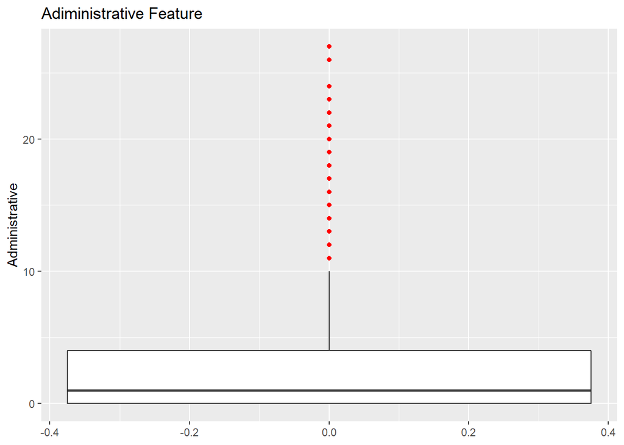

```r
# Distribution
ggplot(data=df, aes(y=Administrative)) +
  geom_boxplot(outlier.colour = 'red') +
  labs(title="Adiministrative Feature")
```

### Administartive Duration

```r
# Mean
aduration.mean <- mean(df$Administrative_Duration)
aduration.mean
```

```
## [1] 81.68214
```

```r
# Mode
aduration.mode <- mode(df$Administrative_Duration)
aduration.mode
```

```
## [1] 0
```

```r
# Median
aduration.median <- median(df$Administrative_Duration)
aduration.median
```

```
## [1] 9
```

```r
# Range
aduration.range <- range(df$Administrative_Duration)
aduration.range
```

```
## [1]   -1.00 3398.75
```

```r
# Standard Deviation
aduration.sd <- sd(df$Administrative_Duration)
aduration.sd
```

```
## [1] 177.5282
```

```r
# Quantiles
aduration.quant <- quantile(df$Administrative_Duration)
aduration.quant
```

```
##      0%     25%     50%     75%    100%
##   -1.00    0.00    9.00   94.75 3398.75
```

```r
# Kurtosis
aduration.kurt <- kurtosis(df$Administrative_Duration)
aduration.kurt
```

```
## [1] 50.08518
```

```r
# Skewness
aduration.skew <- skewness(df$Administrative_Duration)
aduration.skew
```

```
## [1] 5.589523
```

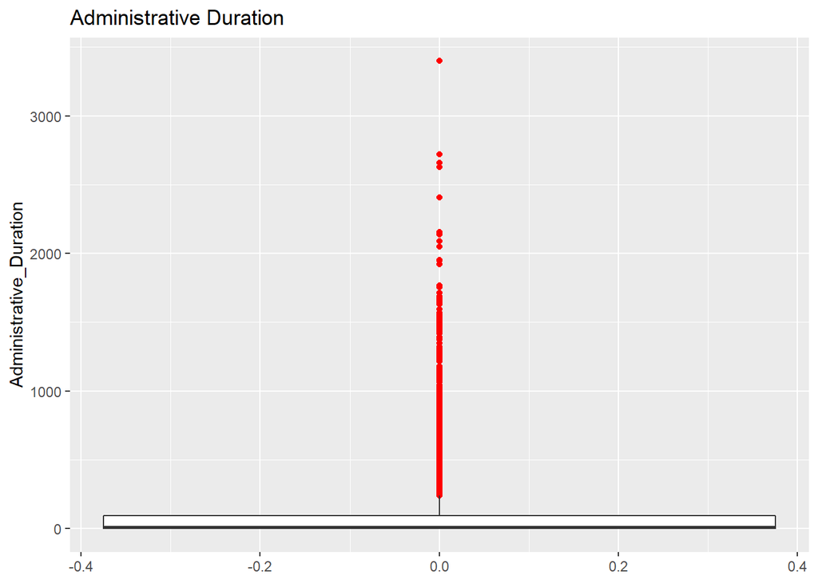

```r
# Distribution

ggplot(data=df, aes(y=Administrative_Duration)) +
  geom_boxplot(outlier.color = "red") +
  labs(title="Administrative Duration")
```

### Informational

```r
# mean
info.mean <- mean(df$Informational)
info.mean
```

```
## [1] 0.5088122
```

```r
# Mode
info.mode <- mode(df$Informational)
info.mode
```

```
## [1] 0
```

```r
# Median
info.median <- median(df$Informational)
info.median
```

```
## [1] 0
```

```r
# Range
info.range <- range(df$Informational)
info.range
```

```
## [1]  0 24
```

```r
# Standard deviation
info.sd <- sd(df$Informational)
info.sd
```

```
## [1] 1.275817
```

```r
# Quantiles
info.quant <- sd(df$Informational)
info.quant
```

```
## [1] 1.275817
```

```r
# Skewness
info.skew <- skewness(df$Informational)
info.skew
```

```
## [1] 4.012958
```

```r
# Kurtosis
info.kurt <- kurtosis(df$Informational)
info.kurt
```

```
## [1] 26.63768
```

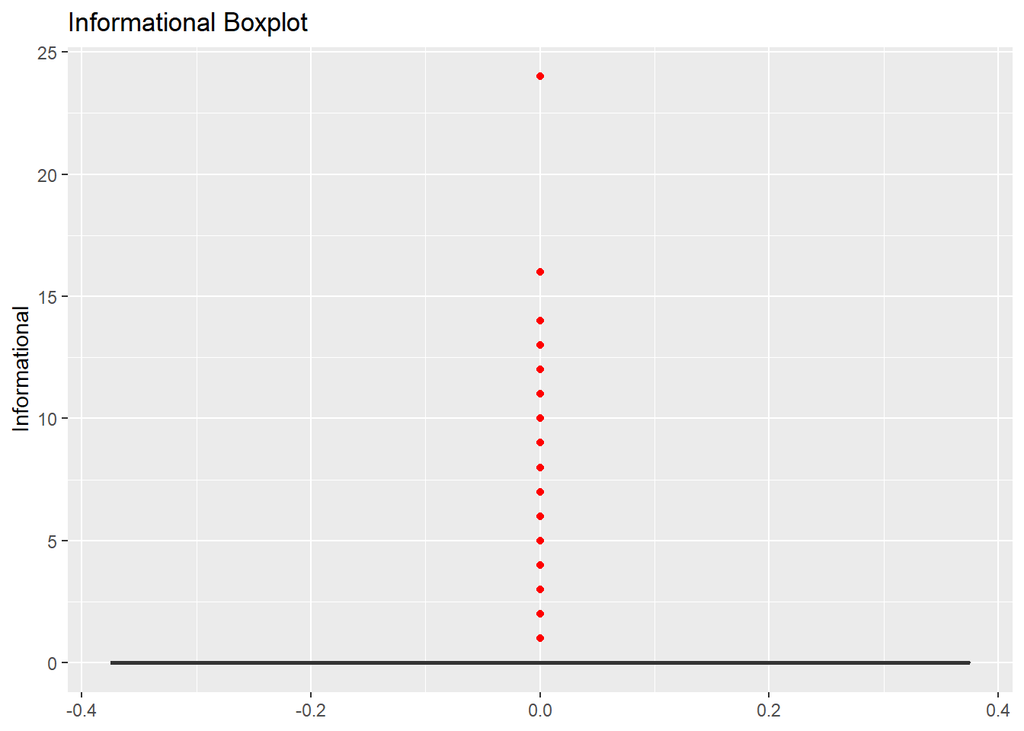

```r
# Distribution
ggplot(data=df, aes(y=Informational)) +
  geom_boxplot(outlier.colour = "red") +
  labs(title="Informational Boxplot")
```

### Informational Duration

```r
# mean
infod.mean <- mean(df$Informational_Duration)
infod.mean
```

```
## [1] 34.83734
```

```r
# Mode
infod.mode <- mode(df$Informational_Duration)
infod.mode
```

```
## [1] 0
```

```r
# Median
infod.median <- median(df$Informational_Duration)
infod.median
```

```
## [1] 0
```

```r
# Range
infod.range <- range(df$Informational_Duration)
infod.range
```

```
## [1]   -1.000 2549.375
```

```r
# Standard deviation
infod.sd <- sd(df$Informational_Duration)
infod.sd
```

```
## [1] 141.4585
```

```r
# Quantiles
infod.quant <- sd(df$Informational_Duration)
infod.quant
```

```
## [1] 141.4585
```

```r
# Skewness
infod.skew <- skewness(df$Informational_Duration)
infod.skew
```

```
## [1] 7.536508
```

```r
# Kurtosis
infod.kurt <- kurtosis(df$Informational_Duration)
infod.kurt
```

```
## [1] 75.45122
```

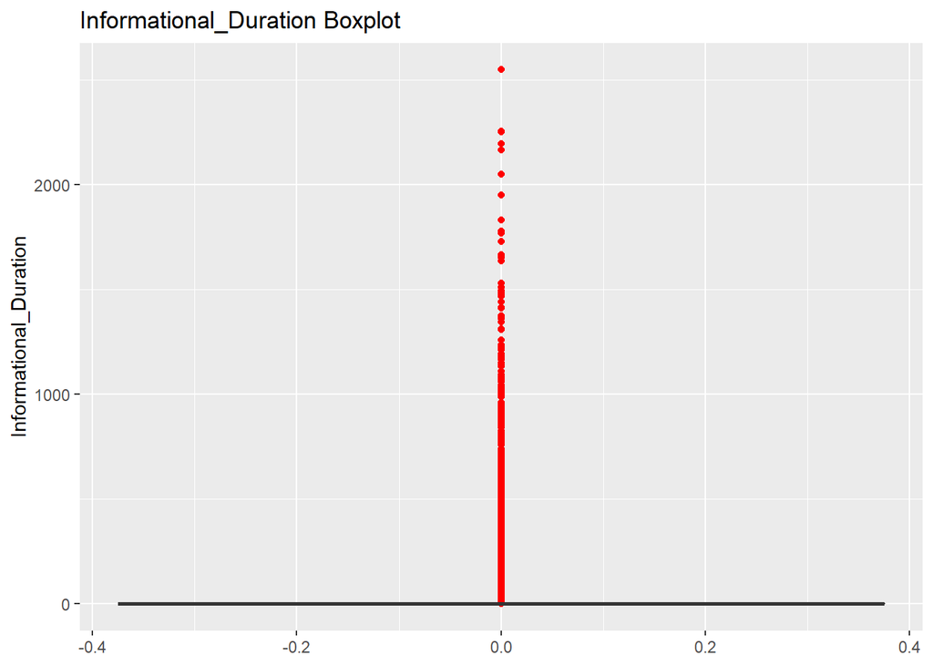

```r
# Distribution
ggplot(data=df, aes(y=Informational_Duration)) +
  geom_boxplot(outlier.colour = "red") +
  labs(title="Informational_Duration Boxplot")
```

### Product Related

```r
# Mean
prod.mean <- mean(df$ProductRelated)
prod.mean
```

```
## [1] 32.05845
```

```r
# Mode
prod.mode <- mode(df$ProductRelated)
prod.mode
```

```
## [1] 1
```

```r
# Median
prod.median <- median(df$ProductRelated)
prod.median
```

```
## [1] 18
```

```r
# Range
prod.range <- range(df$ProductRelated)
prod.range
```

```
## [1]   0 705
```

```r
# Standard deviation
prod.sd <- sd(df$ProductRelated)
prod.sd
```

```
## [1] 44.60091
```

```r
# Quantiles
prod.quant <- quantile(df$ProductRelated)
prod.quant
```

```
##   0%  25%  50%  75% 100%
##    0    8   18   38  705
```

```r
# Kurtosis
prod.kurt <- kurtosis(df$ProductRelated)
prod.kurt
```

```
## [1] 31.04345
```

```r
# Skewness
prod.skew <- skewness(df$ProductRelated)
prod.skew
```

```
## [1] 4.331601
```

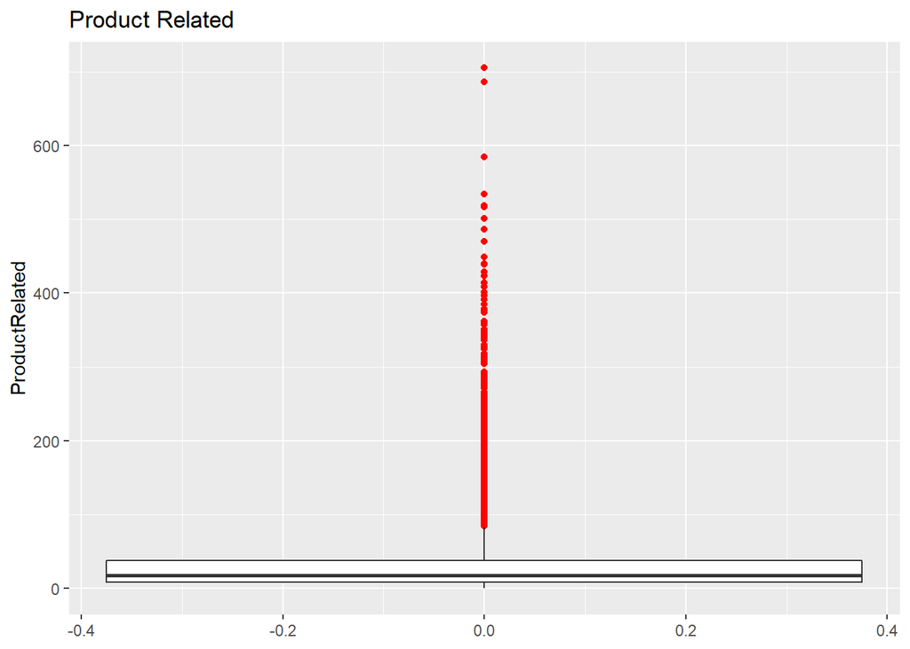

```r
# Distribution
ggplot(df, aes(y=ProductRelated)) +
  geom_boxplot(outlier.colour = "red") +
  labs(title="Product Related")
```

### Product related Duration

```r
# Mean
proddur.mean <- mean(df$ProductRelated_Duration)
proddur.mean
```

```
## [1] 1207.508
```

```r
# Mode
proddur.mode <- mode(df$ProductRelated_Duration)
proddur.mode
```

```
## [1] 0
```

```r
# Median
proddur.median <- median(df$ProductRelated_Duration)
proddur.median
```

```
## [1] 609.5417
```

```r
# Range
proddur.range <- range(df$ProductRelated_Duration)
proddur.range
```

```
## [1]    -1.00 63973.52
```

```r
# Standard deviation
proddur.sd <- sd(df$ProductRelated_Duration)
proddur.sd
```

```
## [1] 1919.927
```

```r
# Quantiles
proddur.quant <- quantile(df$ProductRelated_Duration)
proddur.quant
```

```
##         0%        25%        50%        75%       100%
##    -1.0000   193.5833   609.5417  1477.5648 63973.5222
```

```r
# Kurtosis
proddur.kurt <- kurtosis(df$ProductRelated_Duration)
proddur.kurt
```

```
## [1] 136.5679
```

```r
# Skewness
proddur.skew <- skewness(df$ProductRelated_Duration)
proddur.skew
```

```
## [1] 7.250512
```

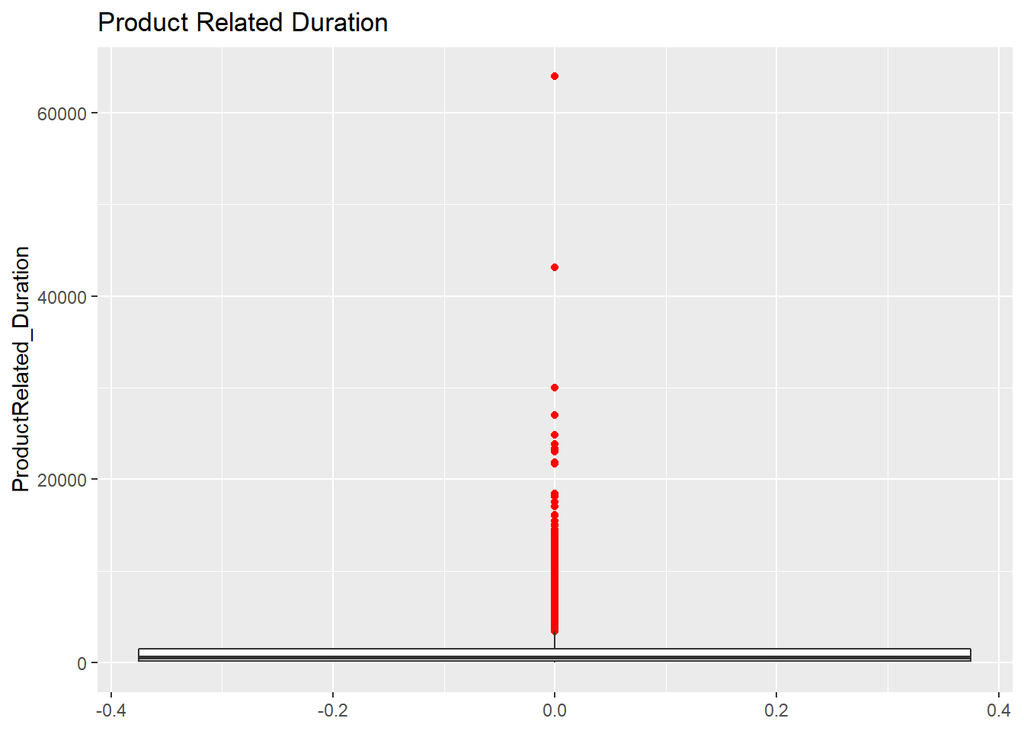

```r
# Distribution
ggplot(df, aes(y=ProductRelated_Duration)) +
  geom_boxplot(outlier.colour = "red") +
  labs(title="Product Related Duration")
```

### Bounce Rate

```r
# Mean
bounce.mean <- mean(df$BounceRates)
bounce.mean
```

```
## [1] 0.02044674
```

```r
# Mode
bounce.mode <- mode(df$BounceRates)
bounce.mode
```

```
## [1] 0
```

```r
# Median
bounce.median <- median(df$BounceRates)
bounce.median
```

```
## [1] 0.002930403
```

```r
# Range
bounce.range <- range(df$BounceRates)
bounce.range
```

```
## [1] 0.0 0.2
```

```r
# Standard Deviation
bounce.sd <- sd(df$BounceRates)
bounce.sd
```

```
## [1] 0.0454025
```

```r
# Quantiles
bounce.quant <- quantile(df$BounceRates)
bounce.quant
```

```
##          0%         25%         50%         75%        100%
## 0.000000000 0.000000000 0.002930403 0.016666667 0.200000000
```

```r
# Kurtosis
bounce.kurt <- kurtosis(df$BounceRates)
bounce.kurt
```

```
## [1] 9.253055
```

```r
# Skewness
bounce.skew <- skewness(df$BounceRates)
bounce.skew
```

```
## [1] 3.152486
```

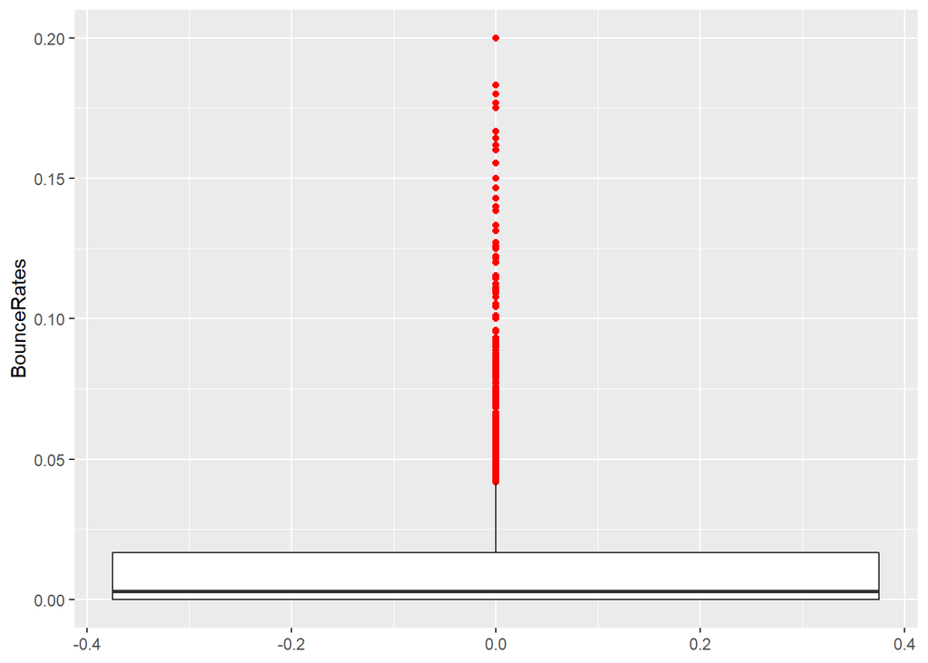

```r
# Distribution
ggplot(df, aes(y=BounceRates)) +
  geom_boxplot(outlier.colour = "red") +
  labs(y="BounceRates")
```

### Exit Rate

```r
# Mean
exit.mean <- mean(df$ExitRates)
exit.mean
```

```
## [1] 0.04149678
```

```r
# Mode
exit.mode <- mode(df$ExitRates)
exit.mode
```

```
## [1] 0.2
```

```r
# Median
exit.median <- median(df$ExitRates)
exit.median
```

```
## [1] 0.025
```

```r
# Range
exit.range <- range(df$ExitRates)
exit.range
```

```
## [1] 0.0 0.2
```

```r
# Standard Deviation
exit.sd <- sd(df$ExitRates)
exit.sd
```

```
## [1] 0.04624716
```

```r
# Quantiles
exit.quant <- quantile(df$ExitRates)
exit.quant
```

```
##         0%        25%        50%        75%       100%
## 0.00000000 0.01422258 0.02500000 0.04848485 0.20000000
```

```r
# Kurtosis
exit.kurt <- kurtosis(df$ExitRates)
exit.kurt
```

```
## [1] 4.623003
```

```r
# Skewness
exit.skew <- skewness(df$ExitRates)
exit.skew
```

```
## [1] 2.232851
```

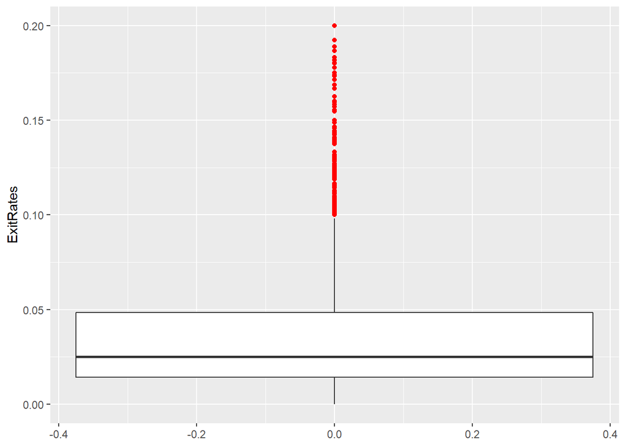

```r
# Distribution
ggplot(df, aes(y=ExitRates)) +
  geom_boxplot(outlier.color = "red")
```

### Page Value

```r
# Mean
page.mean <- mean(df$PageValues)
page.mean
```

```
## [1] 5.9525
```

```r
# Mode
page.mode <- mode(df$PageValues)
page.mode
```

```
## [1] 0
```

```r
# Median
page.median <- median(df$PageValues)
page.median
```

```
## [1] 0
```

```r
# Range
page.range <- range(df$PageValues)
page.range
```

```
## [1]   0.0000 361.7637
```

```r
# Standard Deviatoion
page.sd <- sd(df$PageValues)
page.sd
```

```
## [1] 18.65779
```

```r
# Quantiles
page.quant <- sd(df$PageValues)
page.quant
```

```
## [1] 18.65779
```

```r
# Kurtosis
page.kurt <- kurtosis(df$PageValues)
page.kurt
```

```
## [1] 64.92917
```

```r
# Skewness
page.skew <- skewness(df$PageValues)
page.skew
```

```
## [1] 6.347882
```

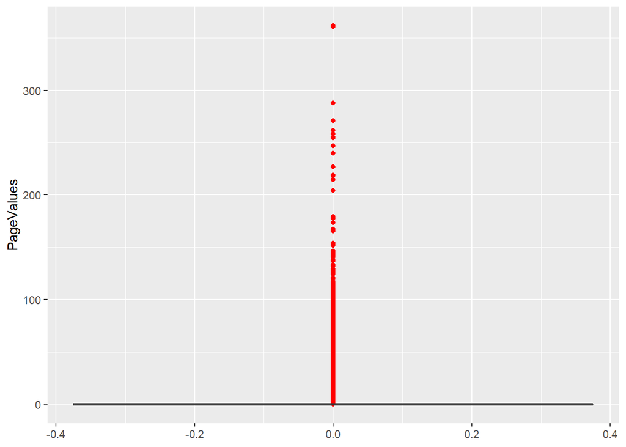

```r
# Distribution

ggplot(df, aes(y=PageValues)) +
  geom_boxplot(outlier.colour = "red")
```

### Special Day

```r
# Mean
special.mean <- mean(df$SpecialDay)
special.mean
```

```
## [1] 0.06197229
```

```r
# Mode
special.mode <- mode(df$SpecialDay)
special.mode
```

```
## [1] 0
```

```r
# Median
special.median <- median(df$SpecialDay)
special.median
```

```
## [1] 0
```

```r
# Range
special.range <- range(df$PageValues)
special.range
```

```
## [1]   0.0000 361.7637
```

```r
# Standard Deviatoion
special.sd <- sd(df$SpecialDay)
special.sd
```

```
## [1] 0.1997106
```

```r
# Quantiles
special.quant <- sd(df$SpecialDay)
special.quant
```

```
## [1] 0.1997106
```

```r
# Kurtosis
special.kurt <- kurtosis(df$SpecialDay)
special.kurt
```

```
## [1] 9.783958
```

```r
# Skewness
special.skew <- skewness(df$SpecialDay)
special.skew
```

```
## [1] 3.284077
```

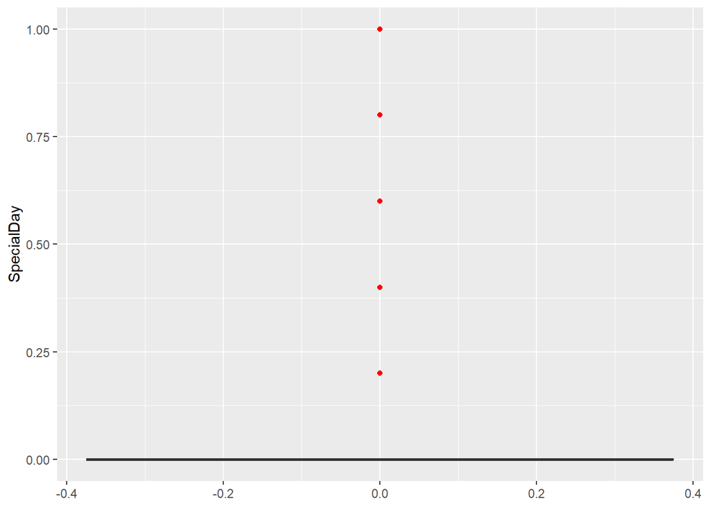

```r
# Distribution

ggplot(df, aes(y=SpecialDay)) +
  geom_boxplot(outlier.colour = "red")
```

### Operating System

```r
# Mode
op.mode <- mode(df$OperatingSystems)
op.mode
```

```
## [1] 2
## Levels: 1 2 3 4 5 6 7 8
```

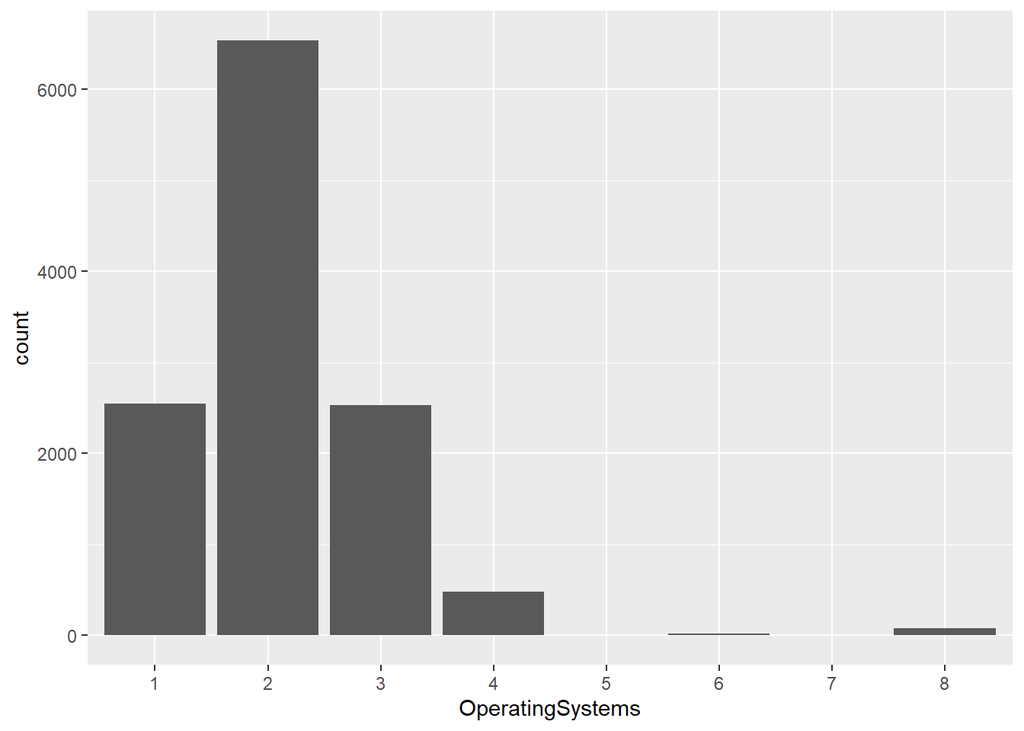

```r
# Distribution
ggplot(df, aes(OperatingSystems)) +
  geom_bar()
```

Most individuals use the 2nd Operating system. Only the first four OSs seem to be popular.

### Browser

```r
# Mode
browser.mode <- mode(df$Browser)
browser.mode
```

```
## [1] 2
## Levels: 1 2 3 4 5 6 7 8 9 10 11 12 13
```

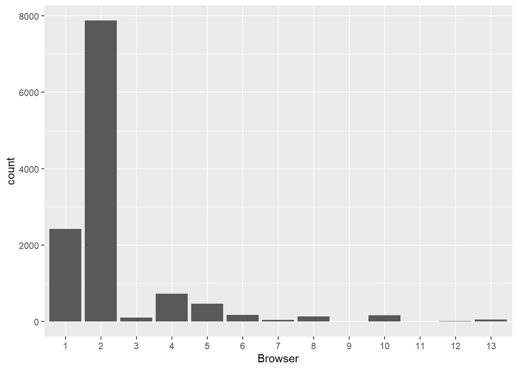

```r
# Distribution
ggplot(df, aes(Browser)) +
  geom_bar()
```

The 2nd browser is the most popular one. Other then the first two, the other browsers barely used by site visitors.

### Traffic Type

```r
# Mode
traffic.mode <- mode(df$TrafficType)
traffic.mode
```

```
## [1] 2
## Levels: 1 2 3 4 5 6 7 8 9 10 11 12 13 14 15 16 17 18 19 20
```

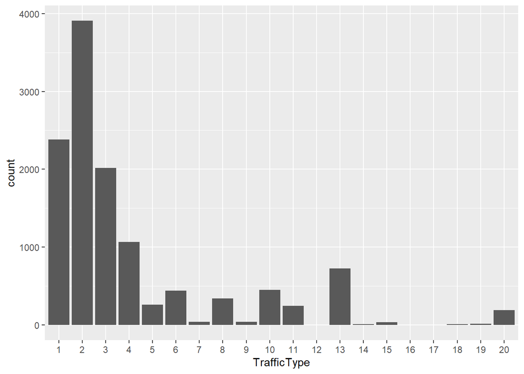

```r
# Distribution
ggplot(df, aes(TrafficType)) +
  geom_bar()
```

The most prevalent traffic type is the second one with 7, 9, 12, 14, 15, 16 ,17, 19, 19 having very low contributions to the pool.

### Visitor Type

```r
# Mode
visitor.mode <- mode(df$VisitorType)
visitor.mode
```

```
## [1] Returning_Visitor
## Levels: New_Visitor Other Returning_Visitor
```

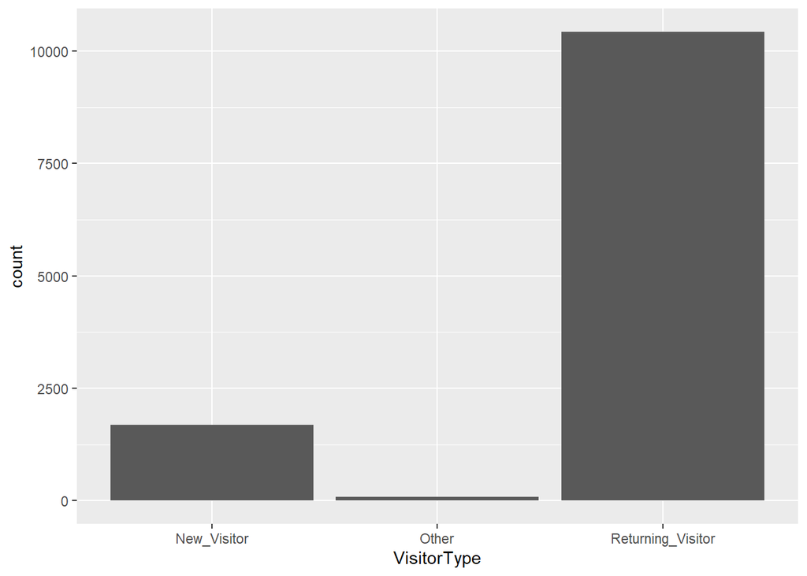

```r
# Distribution
ggplot(df, aes(VisitorType)) +
  geom_bar()
```

Returning Visitors are the most abundant on the website.

### Region

```r
# Mode
region.mode <- mode(df$Region)
region.mode
```

```
## [1] 1
## Levels: 1 2 3 4 5 6 7 8 9
```

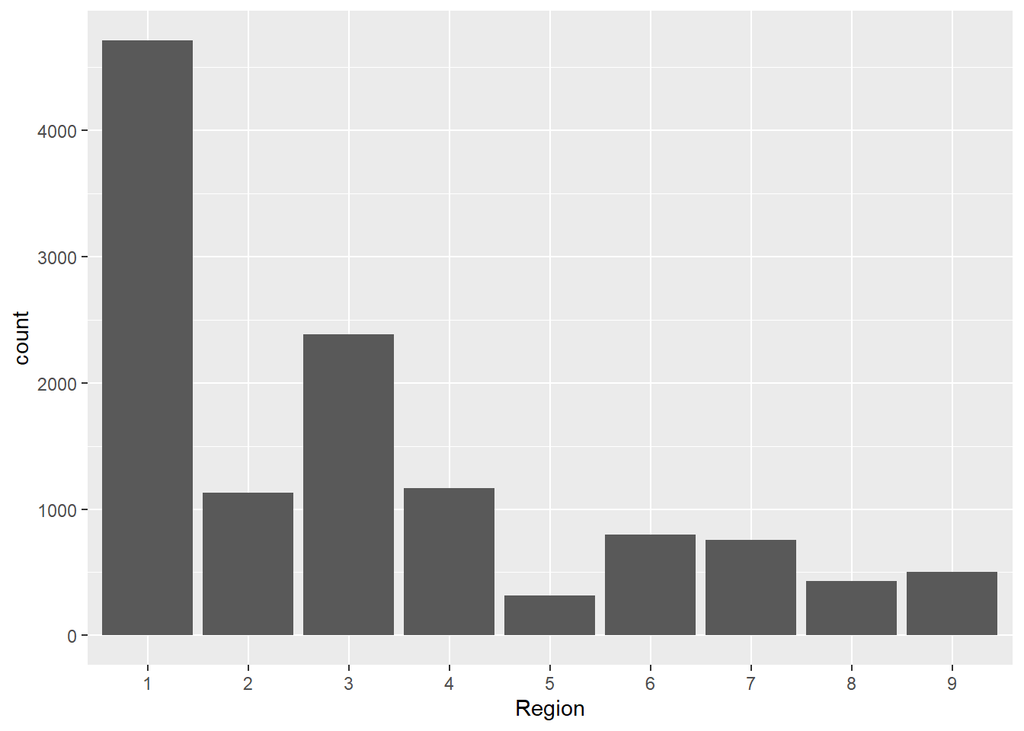

```r
# Distributions
ggplot(df, aes(Region)) +
  geom_bar()
```

The first region contributes the most site users with the rest coming from the others.

### Month

```r
# Mode
month.mode <- mode(df$Month)
month.mode
```

```
## [1] May
## Levels: Aug Dec Feb Jul June Mar May Nov Oct Sep
```

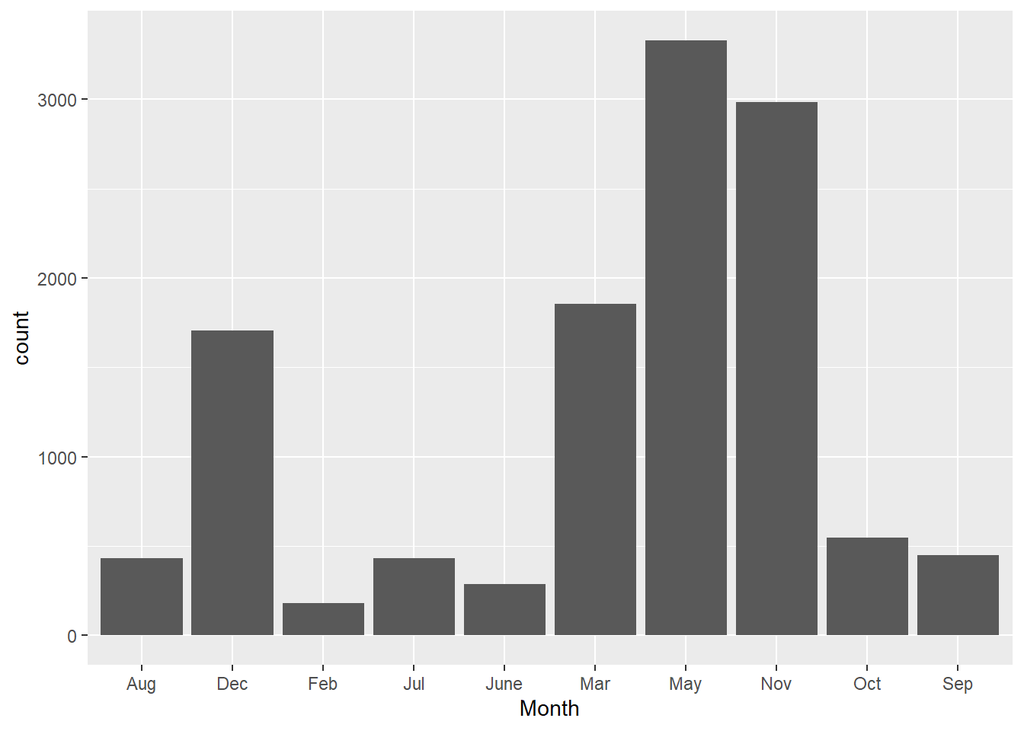

```r
# Distributions
ggplot(df, aes(Month)) +
  geom_bar()
```

The website recieves the most customers in the months of March, May, November and December.

### Weekend

```r
# Mode
wknd.mode <- mode(df$Weekend)
wknd.mode
```

```
## [1] FALSE
## Levels: FALSE TRUE
```

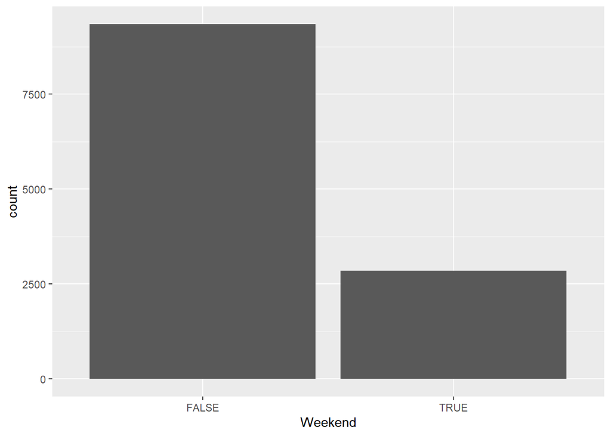

```r
# Distribution
ggplot(df, aes(Weekend)) +
  geom_bar()
```

### Revenue

```r
# Mode
revenue.mode <- mode(df$Revenue)
revenue.mode
```

```
## [1] FALSE
## Levels: FALSE TRUE
```

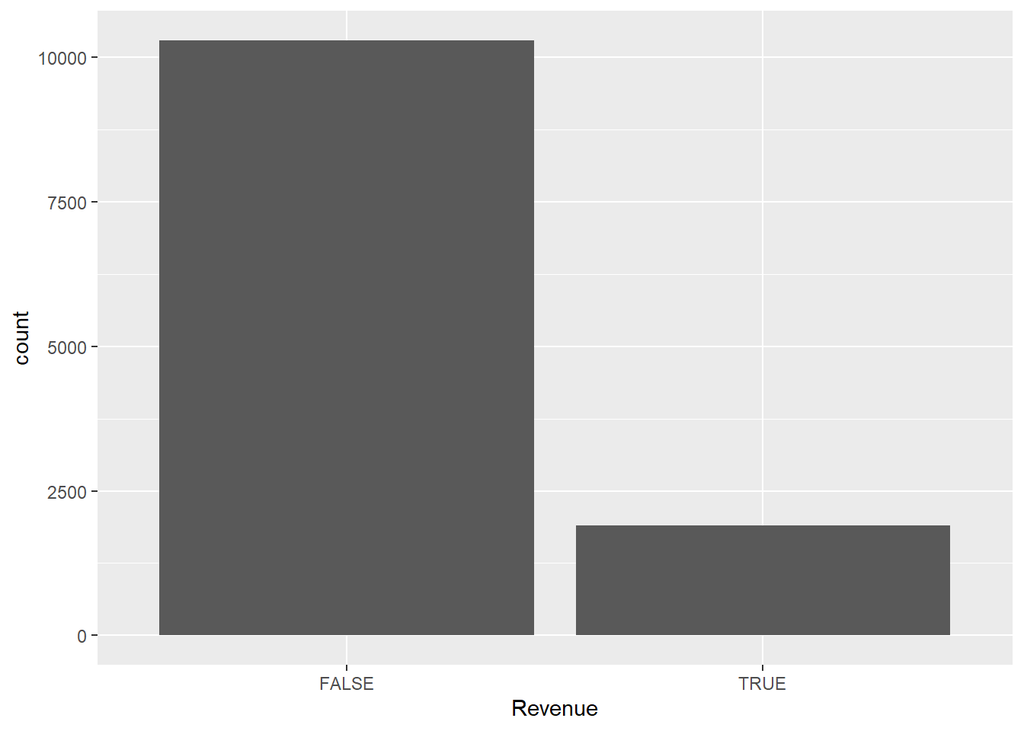

```r
# Distribution
ggplot(df, aes(Revenue)) +
  geom_bar()
```

Most users do not bring in revenue through their activity on the site.

## BIvariate Analysis

Examining how different variables affect the labels

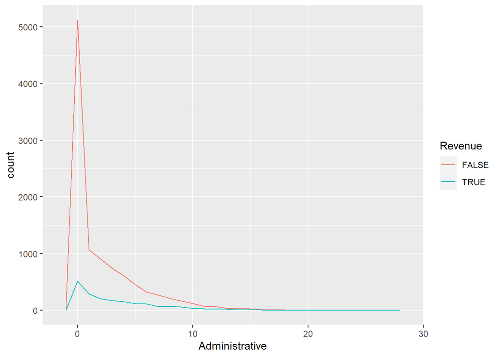

```r
# Administrative sites and Revenue

ggplot(df, aes(Administrative, color=Revenue)) +
  geom_freqpoly(binwidth=1)
```

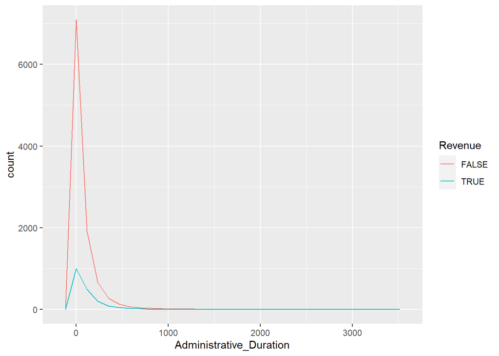

```r
ggplot(df, aes(Administrative_Duration, color=Revenue)) +
  geom_freqpoly()
```

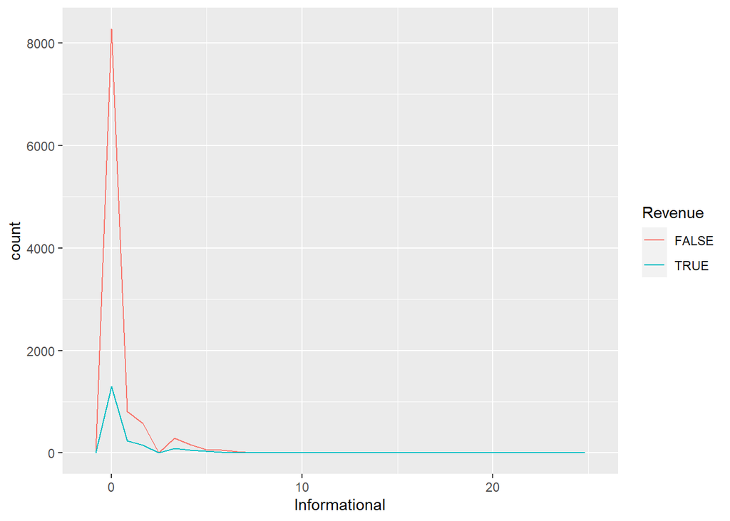

```r
ggplot(df, aes(Informational, color=Revenue)) +
  geom_freqpoly()
```

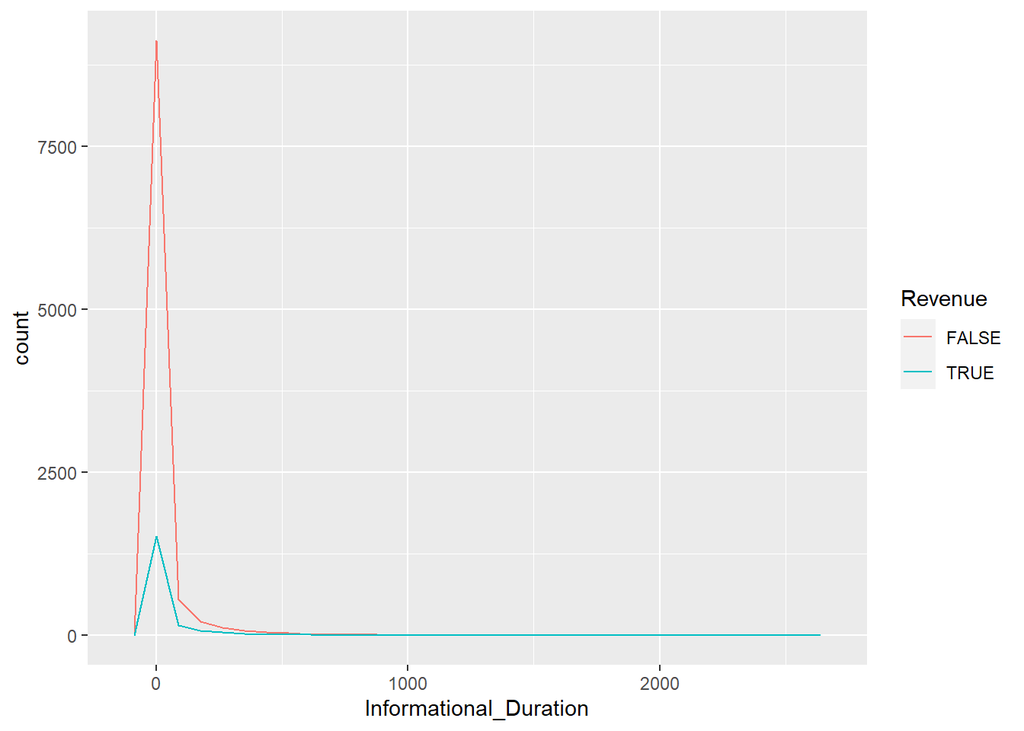

```r
ggplot(df, aes(Informational_Duration, color=Revenue)) +
  geom_freqpoly()
```

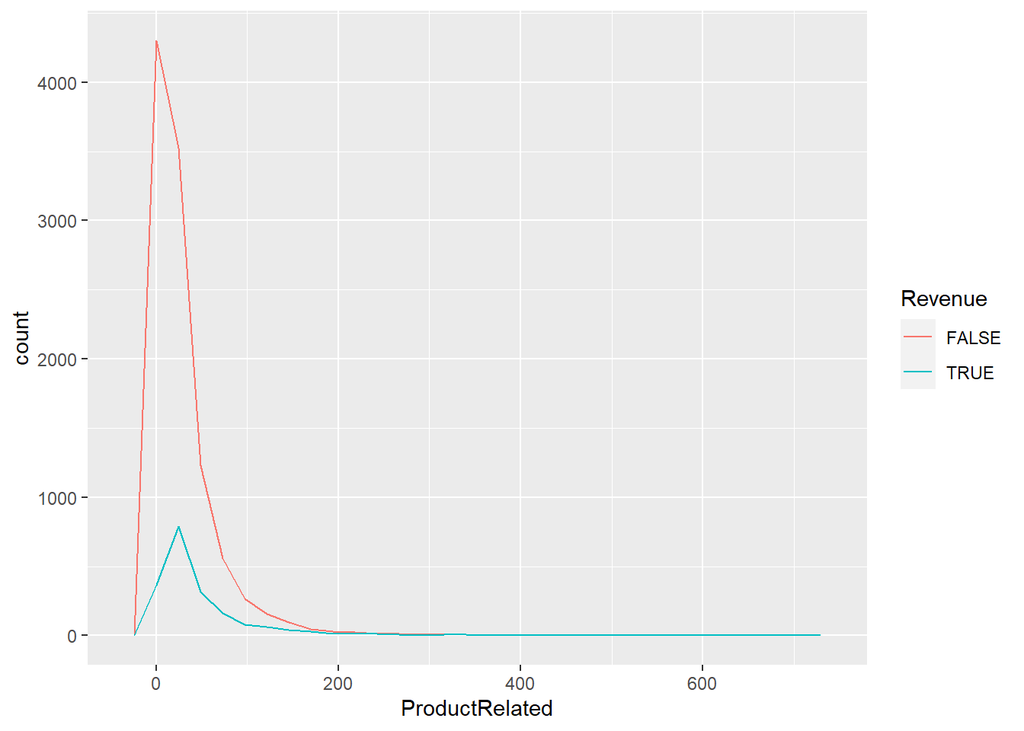

```r
ggplot(df, aes(ProductRelated, color=Revenue)) +
  geom_freqpoly()
```

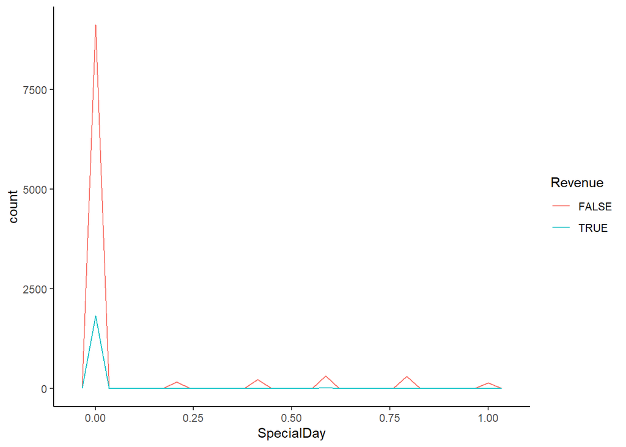

```r
ggplot(df, aes(SpecialDay, color=Revenue)) +
  geom_freqpoly() +
  theme_classic()
```

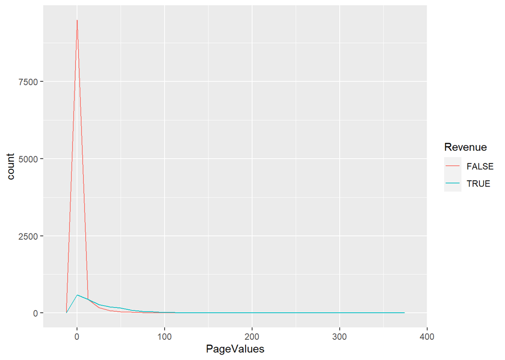

```r
ggplot(df, aes(PageValues, color=Revenue)) +
  geom_freqpoly()
```

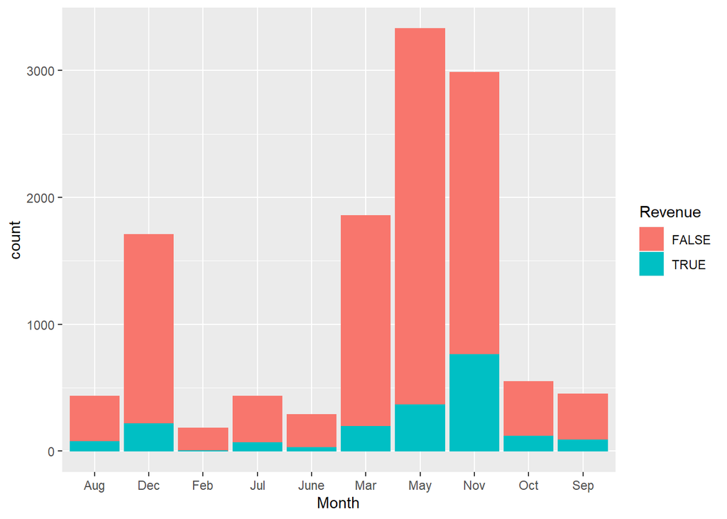

```r
# Months vs GeneratingRevenue

ggplot(df, aes(Month, color=Revenue, fill=Revenue)) +
  geom_bar(binwidth=1)
```

March, May, November and December are the months which generate significantly more revenue for the business.

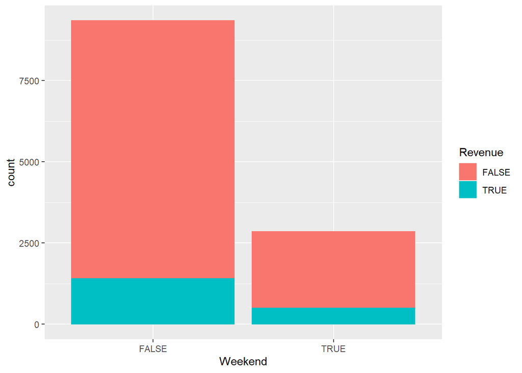

```r
# Day type vs Generating Revenue
ggplot(df, aes(Weekend, color=Revenue, fill=Revenue)) +
  geom_bar(binwidth=1)
```

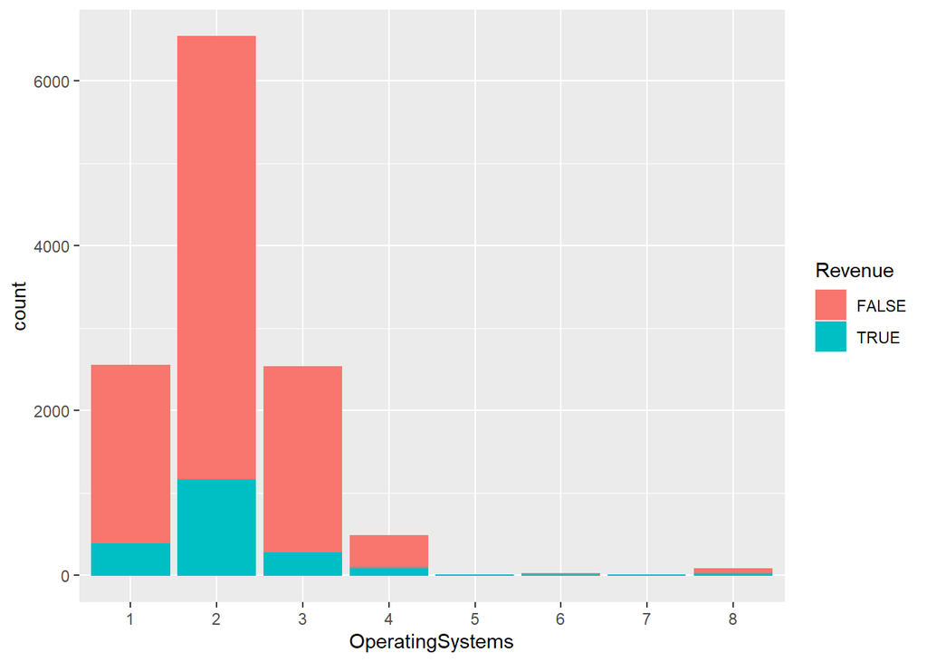

```r
# Operating systems vs Generating Revenue
ggplot(df, aes(OperatingSystems, color=Revenue, fill=Revenue)) +
  geom_bar()
```

Users of type 2 OS generated the most revenue for the site, while 1, and 3 followed.

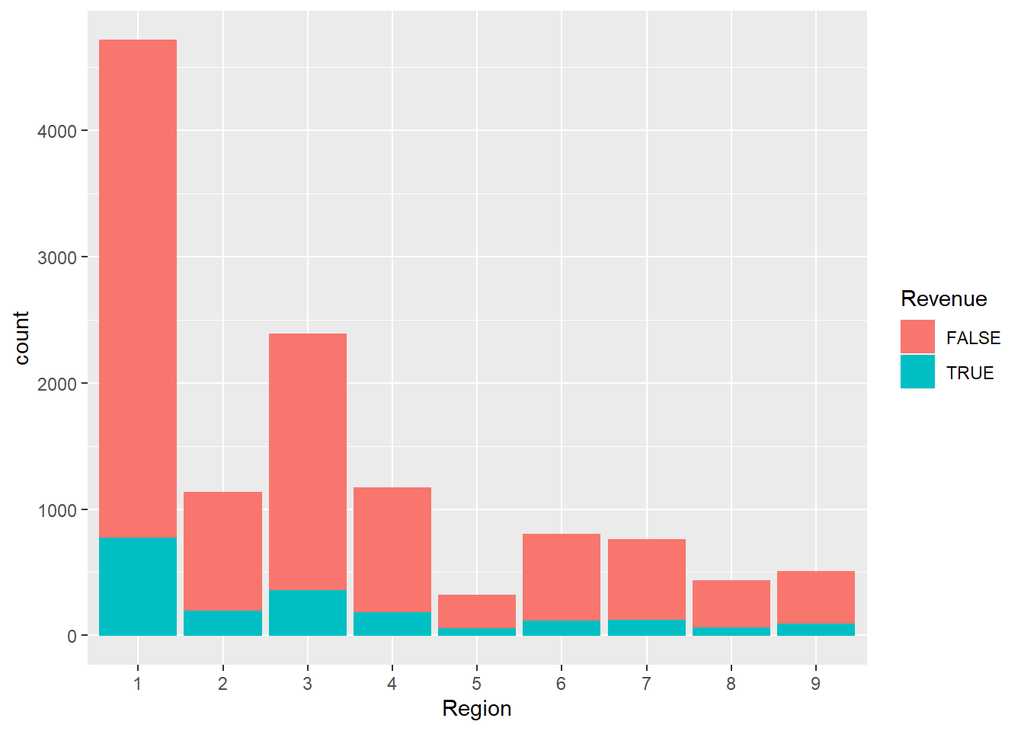

```r
ggplot(df, aes(Region, fill=Revenue, color=Revenue)) +
  geom_bar(binwidth=1)
```

Region 1 produced the most revenue out of all the others with region 5 producing the least.

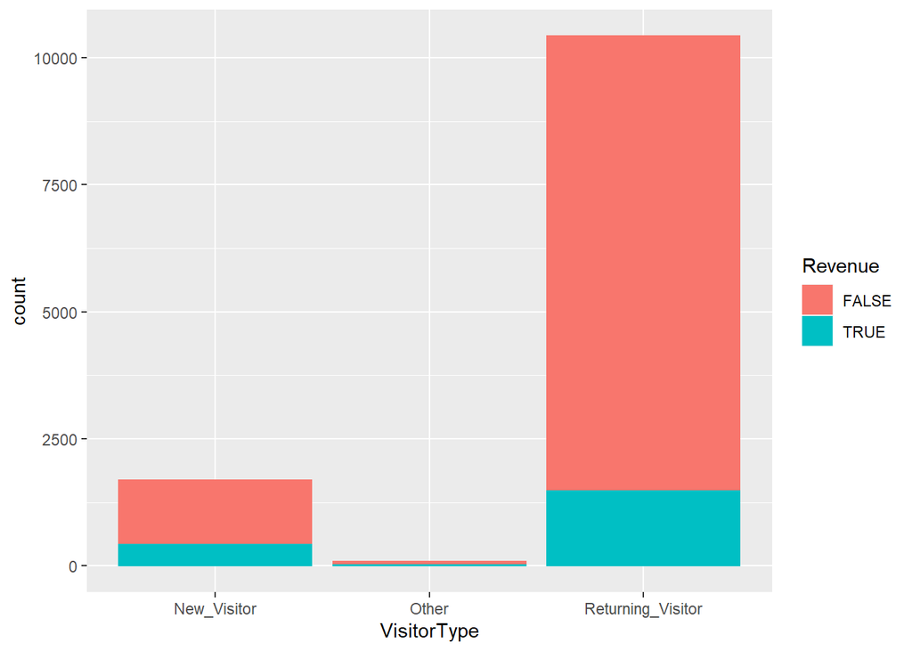

```r
# Visitor type and revenue
ggplot(df, aes(VisitorType, color=Revenue, fill=Revenue)) +
  geom_bar(binwidth=2)
```

Returning visitors generated a lot more revenue than new ones

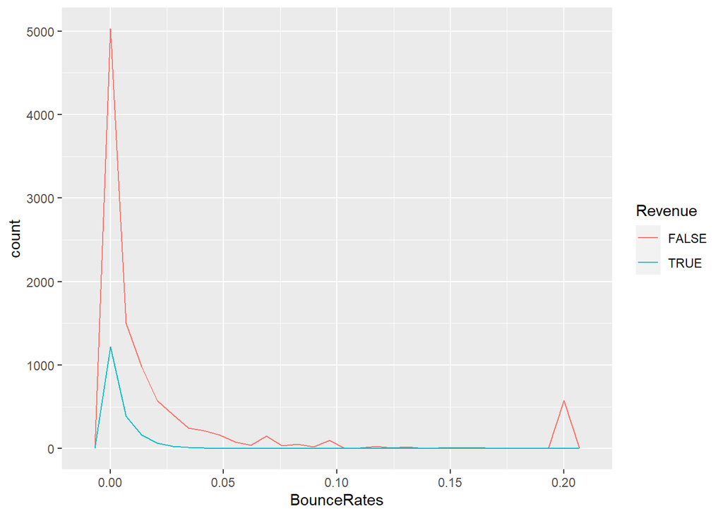

```r
# Bounce rates vs Revenue

ggplot(df, aes(BounceRates, color=Revenue)) +
  geom_freqpoly()
```

### Correlations

```r
cor(df[,unlist(lapply(df, is.numeric))])
```

```
##                         Administrative Administrative_Duration Informational
## Administrative              1.00000000              0.60040965    0.37528761
## Administrative_Duration     0.60040965              1.00000000    0.30143630
## Informational               0.37528761              0.30143630    1.00000000
## Informational_Duration      0.25478602              0.23718986    0.61867795
## ProductRelated              0.42819151              0.28678391    0.37260472
## ProductRelated_Duration     0.37102722              0.35351379    0.38608372
## BounceRates                -0.21366664             -0.13733340   -0.10950530
## ExitRates                  -0.31127413             -0.20202445   -0.15956681
## PageValues                  0.09692097              0.06616837    0.04739015
## SpecialDay                 -0.09707210             -0.07473689   -0.04937677
##                         Informational_Duration ProductRelated
## Administrative                      0.25478602     0.42819151
## Administrative_Duration             0.23718986     0.28678391
## Informational                       0.61867795     0.37260472
## Informational_Duration              1.00000000     0.27906195
## ProductRelated                      0.27906195     1.00000000
## ProductRelated_Duration             0.34658069     0.86030819
## BounceRates                        -0.07015947    -0.19351577
## ExitRates                          -0.10293268    -0.28616321
## PageValues                          0.03006416     0.05411549
## SpecialDay                         -0.03129304    -0.02593062
##                         ProductRelated_Duration BounceRates  ExitRates
## Administrative                       0.37102722 -0.21366664 -0.3112741
## Administrative_Duration              0.35351379 -0.13733340 -0.2020245
## Informational                        0.38608372 -0.10950530 -0.1595668
## Informational_Duration               0.34658069 -0.07015947 -0.1029327
## ProductRelated                       0.86030819 -0.19351577 -0.2861632
## ProductRelated_Duration              1.00000000 -0.17437550 -0.2453340
## BounceRates                         -0.17437550  1.00000000  0.9033582
## ExitRates                           -0.24533401  0.90335819  1.0000000
## PageValues                           0.05084062 -0.11599198 -0.1735715
## SpecialDay                          -0.03821065  0.08783999  0.1167838
##                          PageValues  SpecialDay
## Administrative           0.09692097 -0.09707210
## Administrative_Duration  0.06616837 -0.07473689
## Informational            0.04739015 -0.04937677
## Informational_Duration   0.03006416 -0.03129304
## ProductRelated           0.05411549 -0.02593062
## ProductRelated_Duration  0.05084062 -0.03821065
## BounceRates             -0.11599198  0.08783999
## ExitRates               -0.17357154  0.11678376
## PageValues               1.00000000 -0.06453271
## SpecialDay              -0.06453271  1.00000000
```

The rates were significantly correlated while types of number of sites were strongly correlated with how much time was spent in them.

## Solution Implementation using Clustering

### Data Preparation

```r
# label encoding
month <- LabelEncoder.fit(df$Month)
df$Month <- transform(month, factor(df$Month))

wknd <- LabelEncoder.fit(df$Weekend)
df$Weekend <- transform(wknd, factor(df$Weekend))

visitor <- LabelEncoder.fit(df$VisitorType)
df$VisitorType <- transform(visitor, factor(df$VisitorType))


head(df)
```

```
##   Administrative Administrative_Duration Informational Informational_Duration
## 1              0                       0             0                      0
## 2              0                       0             0                      0
## 3              0                      -1             0                     -1
## 4              0                       0             0                      0
## 5              0                       0             0                      0
## 6              0                       0             0                      0
##   ProductRelated ProductRelated_Duration BounceRates ExitRates PageValues
## 1              1                0.000000  0.20000000 0.2000000          0
## 2              2               64.000000  0.00000000 0.1000000          0
## 3              1               -1.000000  0.20000000 0.2000000          0
## 4              2                2.666667  0.05000000 0.1400000          0
## 5             10              627.500000  0.02000000 0.0500000          0
## 6             19              154.216667  0.01578947 0.0245614          0
##   SpecialDay Month OperatingSystems Browser Region TrafficType VisitorType
## 1          0     3                1       1      1           1           3
## 2          0     3                2       2      1           2           3
## 3          0     3                4       1      9           3           3
## 4          0     3                3       2      2           4           3
## 5          0     3                3       3      1           4           3
## 6          0     3                2       2      1           3           3
##   Weekend Revenue
## 1       1   FALSE
## 2       1   FALSE
## 3       1   FALSE
## 4       1   FALSE
## 5       2   FALSE
## 6       1   FALSE
```

### KMEANS CLUSTERING

```r
# separating features from Revenue labels

x <- df[, -18]

# normalizing
normalize <- function(x){
  return ((x-min(x)) / (max(x)-min(x)))
}

x$Administrative <- normalize(x$Administrative)
x$Administrative_Duration <- normalize(x$Administrative_Duration)
x$Informational <- normalize(x$Informational)
x$Informational_Duration <- normalize(x$Informational_Duration)
x$ProductRelated <- normalize(x$ProductRelated)
x$ProductRelated_Duration <- normalize(x$ProductRelated_Duration)
x$BounceRates <- normalize(x$BounceRates)
x$ExitRates <- normalize(x$ExitRates)
x$PageValues <- normalize(x$PageValues)
x$SpecialDay <- normalize(x$SpecialDay)
```

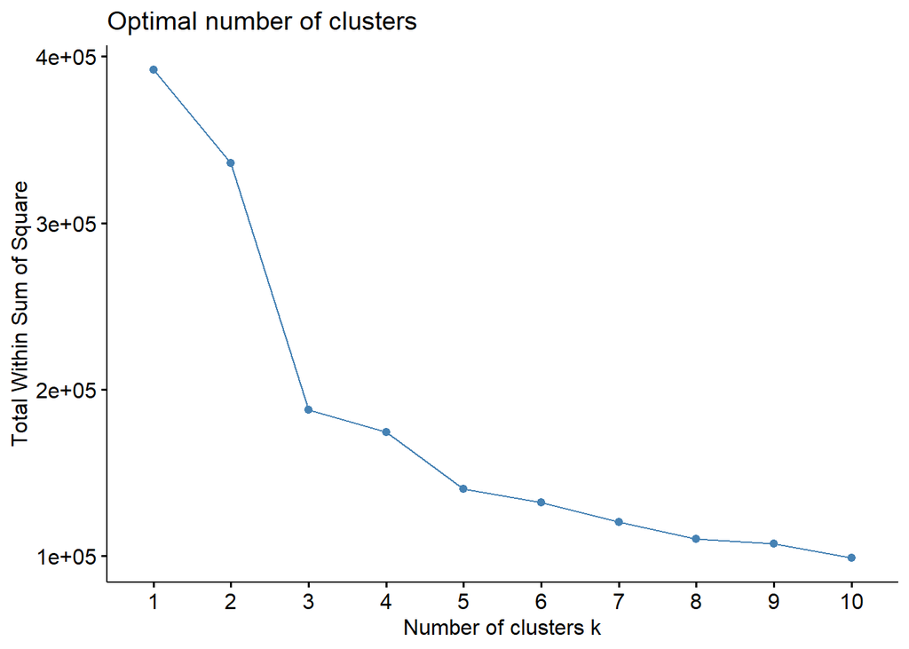

```r
# finding optimum k

fviz_nbclust(x, kmeans, method="wss")
```

According to the elbow plot above, only 3 clusters are sufficient. This shall be cross checked using the silhouette method

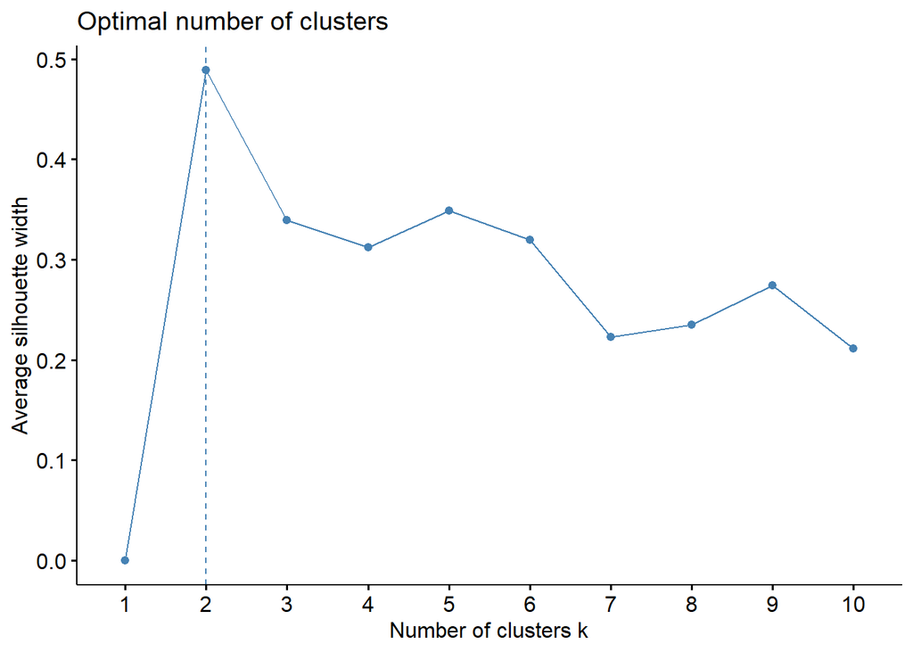

```r
# silhouette method
fviz_nbclust(x, kmeans, method="silhouette")
```

```r
# Using 3 clusters
k <- kmeans(x, centers=3, nstart=25)
```

```r
# Number of records in each cluster
k$size
```

```
## [1] 1993 7784 2422
```

```r
str(k)
```

```
## List of 9
##  $ cluster     : Named int [1:12199] 3 3 3 3 3 3 3 3 3 3 ...
##   ..- attr(*, "names")= chr [1:12199] "1" "2" "3" "4" ...
##  $ centers     : num [1:3, 1:17] 0.0781 0.0891 0.086 0.0233 0.0247 ...
##   ..- attr(*, "dimnames")=List of 2
##   .. ..$ : chr [1:3] "1" "2" "3"
##   .. ..$ : chr [1:17] "Administrative" "Administrative_Duration" "Informational" "Informational_Duration" ...
##  $ totss       : num 391846
##  $ withinss    : num [1:3] 57682 97131 32945
##  $ tot.withinss: num 187758
##  $ betweenss   : num 204089
##  $ size        : int [1:3] 1993 7784 2422
##  $ iter        : int 3
##  $ ifault      : int 0
##  - attr(*, "class")= chr "kmeans"
```

```r
df$cluster <- as.factor(k$cluster)
head(df)
```

```
##   Administrative Administrative_Duration Informational Informational_Duration
## 1              0                       0             0                      0
## 2              0                       0             0                      0
## 3              0                      -1             0                     -1
## 4              0                       0             0                      0
## 5              0                       0             0                      0
## 6              0                       0             0                      0
##   ProductRelated ProductRelated_Duration BounceRates ExitRates PageValues
## 1              1                0.000000  0.20000000 0.2000000          0
## 2              2               64.000000  0.00000000 0.1000000          0
## 3              1               -1.000000  0.20000000 0.2000000          0
## 4              2                2.666667  0.05000000 0.1400000          0
## 5             10              627.500000  0.02000000 0.0500000          0
## 6             19              154.216667  0.01578947 0.0245614          0
##   SpecialDay Month OperatingSystems Browser Region TrafficType VisitorType
## 1          0     3                1       1      1           1           3
## 2          0     3                2       2      1           2           3
## 3          0     3                4       1      9           3           3
## 4          0     3                3       2      2           4           3
## 5          0     3                3       3      1           4           3
## 6          0     3                2       2      1           3           3
##   Weekend Revenue cluster
## 1       1   FALSE       3
## 2       1   FALSE       3
## 3       1   FALSE       3
## 4       1   FALSE       3
## 5       2   FALSE       3
## 6       1   FALSE       3
```